# StormData

Andriy Levytskyy

18/09/2020

# Relation of Severe Weather Events on Public Health and Economy

## Data Processing

**Assumptions**: * The file has been download to the current working directory * The file was named StormData.csv.bz2

**Performed steps**: * Load the data from bzipped file * Calculate the damage * Using Logic, it was found that the exponential has lots of values that were not explained in the documentation. These values were ignored. Only K, M, B were understood as 1000, 10^6 and 10^9, respectively. * Property damage & crop damage were summed up to get the total damage * Calculate total fatalities and injuries * Plot top 10 event

```r
# Load Libraries
library(dplyr)
```

```r
library(ggplot2)

filename<-"StormData.csv.bz2"

# Download file

if(!file.exists(filename)){
  fileURL <- "https://d396qusza40orc.cloudfront.net/repdata%2Fdata%2FStormData.csv.bz2"
  download.file(fileURL, filename, method = "curl")
}

# Read data

StormData<-read.csv("StormData.csv.bz2", header = TRUE)

StormData_by_evtype<-group_by(StormData, EVTYPE)

StormData_sum_by_evtype<-summarise(StormData_by_evtype,
                                  SumFATALITIES=sum(FATALITIES), SumINJURIES=sum(INJURIES),
                                  TotalHealth=SumFATALITIES+SumINJURIES)
StormData_sum_by_evtype<-StormData_sum_by_evtype[order(StormData_sum_by_evtype$TotalHealth, decreasing = TRUE), ]

StormData_sum_by_evtype_top10<-head(StormData_sum_by_evtype, 10)
```

## Results

### Impact on Population health

Across the United States, which types of events (as indicated in the EVTYPE variable) are most harmful with respect to population health?

```r
# top 10 by Total health damage
StormData_sum_by_evtype_top10
```

```
## # A tibble: 10 x 4
##    EVTYPE            SumFATALITIES SumINJURIES TotalHealth
##    <chr>                     <dbl>       <dbl>       <dbl>
##  1 TORNADO                    5633       91346       96979
##  2 EXCESSIVE HEAT             1903        6525        8428
##  3 TSTM WIND                   504        6957        7461
##  4 FLOOD                       470        6789        7259
##  5 LIGHTNING                   816        5230        6046
##  6 HEAT                        937        2100        3037
##  7 FLASH FLOOD                 978        1777        2755
##  8 ICE STORM                    89        1975        2064
##  9 THUNDERSTORM WIND           133        1488        1621
## 10 WINTER STORM                206        1321        1527
```

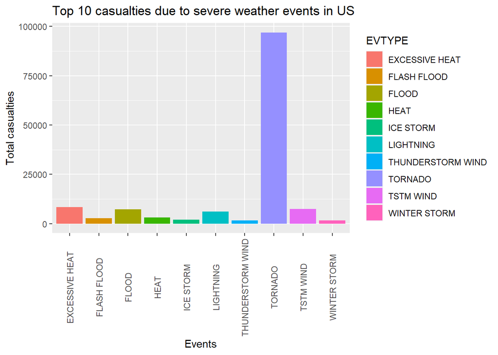

```r
# Plot top 10
ggplot(StormData_sum_by_evtype_top10, aes(x=EVTYPE, y=TotalHealth, fill=EVTYPE)) +
  geom_bar(stat="identity") +
  ggtitle("Top 10 casualties due to severe weather events in US") +
  xlab("Events") +
  ylab("Total casualties") +
  theme(axis.text.x = element_text(angle = 90, vjust=0.5))
```

From the figure, it was found that Tornado has caused the most number of injuries and fatalities (96,979 fatalities and injuries), significantly more than any other type of events.

### Impact on Economy

```r
StormData_by_evtype<-mutate(StormData_by_evtype, PropDamage = ifelse(PROPDMGEXP == "", PROPDMG, 0 ))

StormData_by_evtype$PropDamage<-with(StormData_by_evtype,
                                     ifelse(PROPDMGEXP == "K", PROPDMG*1000+PropDamage, PropDamage))

StormData_by_evtype$PropDamage<-with(StormData_by_evtype,
                                     ifelse(PROPDMGEXP == "M", PROPDMG*1000000+PropDamage, PropDamage ))

StormData_by_evtype$PropDamage<-with(StormData_by_evtype,
                                     ifelse(PROPDMGEXP == "B", PROPDMG*1000000000+PropDamage, PropDamage ))


StormData_by_evtype<-mutate(StormData_by_evtype, CropDamage = ifelse(CROPDMGEXP == "", CROPDMG, 0 ))

StormData_by_evtype$CropDamage<-with(StormData_by_evtype,
                                     ifelse(CROPDMGEXP == "K", CROPDMG*1000+CropDamage, CropDamage))

StormData_by_evtype$CropDamage<-with(StormData_by_evtype,
                                     ifelse(CROPDMGEXP == "M", CROPDMG*1000000+CropDamage, CropDamage ))

StormData_by_evtype$CropDamage<-with(StormData_by_evtype,
                                     ifelse(CROPDMGEXP == "B", CROPDMG*1000000000+CropDamage, CropDamage ))


StormData_sum_damage_by_evtype<-summarise(StormData_by_evtype,
                                   SumPropDamage=sum(PropDamage), SumCropDamage=sum(CropDamage),
                                   TotalDamage=SumPropDamage+SumCropDamage)
StormData_sum_damage_by_evtype<-StormData_sum_damage_by_evtype[order(StormData_sum_damage_by_evtype$TotalDamage, decreasing = TRUE), ]


StormData_sum_damage_by_evtype_top10<-head(StormData_sum_damage_by_evtype, 10)

StormData_sum_damage_by_evtype_top10
```

```
## # A tibble: 10 x 4
##    EVTYPE            SumPropDamage SumCropDamage  TotalDamage
##    <chr>                     <dbl>         <dbl>        <dbl>
##  1 FLOOD              144657709807    5661968450 150319678257
##  2 HURRICANE/TYPHOON   69305840000    2607872800  71913712800
##  3 TORNADO             56925660483     414953110  57340613593
##  4 STORM SURGE         43323536000          5000  43323541000
##  5 HAIL                15727366777    3025537453  18752904230
##  6 FLASH FLOOD         16140811717    1421317100  17562128817
##  7 DROUGHT              1046106000   13972566000  15018672000
##  8 HURRICANE           11868319010    2741910000  14610229010
##  9 RIVER FLOOD          5118945500    5029459000  10148404500
## 10 ICE STORM            3944927810    5022113500   8967041310
```

[figure not shown]

```r
ggplot(StormData_sum_damage_by_evtype_top10, aes(x=EVTYPE, y=TotalDamage, fill=EVTYPE)) +
  geom_bar(stat="identity") +
  ggtitle("Top 10 weather economic consequences events in US") +
  xlab("Events") +
  ylab("Total damage in millions USD") +
  theme(axis.text.x = element_text(angle = 90, vjust=0.5))
```

From the figure, it was found that Flood has caused biggest damage (around 150 billions US dollars), much higher than any other events.